Theobio main page

# Ontario COVID-19 forecasts

[#MacTheobio COVID Modelling Group](https://mac-theobio.github.io/covid-19/)

Irena Papst* ([@irenapapst](https://twitter.com/irenapapst)), Michael Li* ([@MLiwz1](https://twitter.com/MLiwz1)), Ben Bolker ([@bolkerb](https://twitter.com/bolkerb)), Jonathan Dushoff ([@jd_mathbio](https://twitter.com/jd_mathbio)), David Earn ([@DavidJDEarn](https://twitter.com/davidjdearn))

McMaster University, Hamilton, Ontario, Canada, L8S 4K1

The first two authors contributed equally

Forecast date: 5 June 2021

*Post last updated: 21 Jun 2021*

# Context

Every three weeks, [our group](https://mac-theobio.github.io/covid-19/) provides COVID-19 infection report forecasts for the province of Ontario to the [Ontario Modelling Consensus Table](https://covid19-sciencetable.ca/our-partners/) (MCT), a partner of the [Ontario Science Advisory Table](https://covid19-sciencetable.ca) (SAT), which presents this information to the Health Coordination Table of the Ontario Ministry of Health.[^1] Other modelling groups also provide forecasts to the MCT. After reviewing all forecasts provided, the MCT provides consensus projections to the SAT.

Our forecasts are based on a [compartmental epidemic model](https://en.wikipedia.org/wiki/Compartmental_models_in_epidemiology) implemented in our publicly available [`McMasterPandemic`](https://github.com/bbolker/McMasterPandemic) R package, and involve statistical fits to [Ontario’s latest infection report data](https://covid-19.ontario.ca/data).

# Forecast overview

The forecast presented here was made on **5 Jun 2021** and submitted to the MCT for inclusion in the public briefing by the SAT on 10 June.

This set of forecasts incorporates an enhanced **two-dose vaccination model**, as well as the projected replacement of the **Alpha** [Variant of Concern](https://www.who.int/en/activities/tracking-SARS-CoV-2-variants/) (VoC), also known as B.1.1.7, by the more-transmissible **Delta** VoC (B.1.617.2).

We have updated, and will continue to update, this post in order to show the [latest infection reports](https://covid-19.ontario.ca/data), but the forecasts themselves have not, and will not, be modified after the forecast date.

# Forecast results

The following figure gives the infection report forecasts (curves), with 95% confidence intervals as bands around each forecast curve. Observed infection reports to which the model was fit are plotted with **solid points**, while observations after the fact are included as **hollow points**.

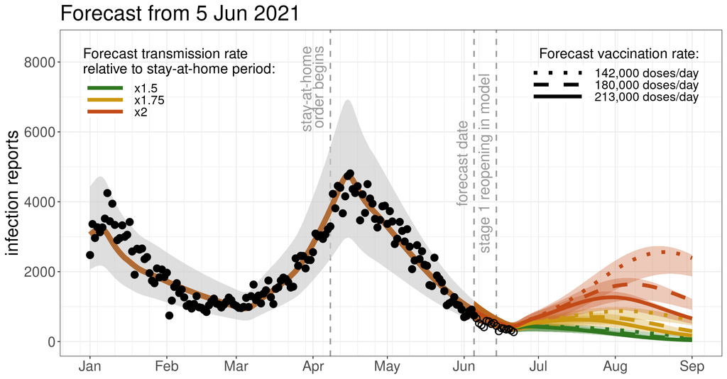

# Forecast details

## Interventions

We assume public health measures relax on 14 June, which (at the time the forecast was made) was the scheduled date for the province to move into stage 1 of its [reopening plan](https://www.ontario.ca/page/reopening-ontario) (re-opening has since been moved up to 11 June). We explore 3 scenarios for the transmission rate upon reopening (due to increased contacts):

1. x1.5 the estimated transmission rate under the stay-at-home order (a 50% increase);
2. x1.75 (a 75% increase);
3. x2 (a 100% increase).

We assume that the lifting of the 8 April stay-at-home order on 2 June has not had a significant effect on contacts (on 5 June it was too soon to estimate any such effect from infection report data due to the approximate 14-day reporting delay for infections).

## Vaccination

For the model fitting period, we feed in the [reported number of first and second doses administered each day](https://covid19tracker.ca/provincevac.html?p=ON).

In the forecast period, we explore 3 scenarios for the total number of doses administered per day:

1. **142,000 doses/day** (average rate for seven days up to and including the forecast date of 5 June);
2. **180,000 doses/day** (a 27% increase over the seven-day average);
3. **213,000 doses/day** (a 50% increase over the seven-day average).

In each scenario, the total dose administration rate remains constant throughout the forecast period.

We assume that the proportion of first doses administered follows a logistic curve starting on the forecast date, based on fitting the reported proportion of first doses starting from 1 May:

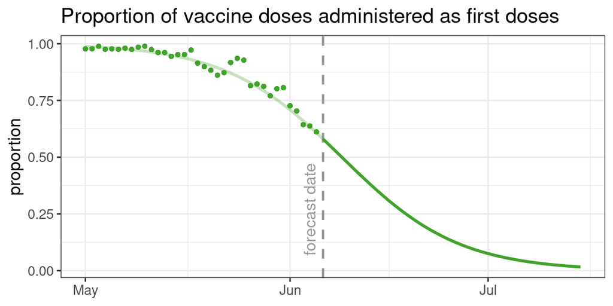

The green points are reported first dose proportions and the green line gives the projected proportions based on a logistic fit.

The vaccination model includes the following assumptions:

1. Infection-blocking vaccine efficacy is 60% for the first dose and 90% for the second dose. We do not explicitly model any decreases in vaccine efficacy due to increased frequency of the Delta variant.
2. Vaccine-derived immunity takes an average of 14 days to develop after a dose is administered.
3. If a vaccinated individual is infected, their probability of having a less-transmissible, asymptomatic infection increases with each dose (20% for the unvaccinated, 60% for those protected by one dose, and 90% for those protected by two doses).
4. Vaccines are administered at random in the population (we do not explicitly account for age or other characteristics of individuals).

## Takeover by the Delta Variant of Concern

The Alpha VoC is currently dominant in Ontario, but the share of infection reports attributed to the more-transmissible Delta variant has been [increasing steadily](https://www.publichealthontario.ca/-/media/documents/ncov/epi/covid-19-sars-cov2-whole-genome-sequencing-epi-summary.pdf?la=en). We incorporate further increases to the transmission rate (beyond the increases caused by a higher contact rate upon reopening) based on the projected replacement of Alpha by Delta, using a model that makes the following assumptions:

1. The daily proportion of infection reports attributed to the Delta VoC follows a logistic curve, as derived in [Day & Gandon 2007](https://doi.org/10.1111/j.1461-0248.2007.01091.x).
2. The speed of the replacement of Alpha by Delta is based on the assumption that Delta is 50% more transmissible than Alpha (*i.e.*, it increases the existing transmission rate by a factor of 1.5).

The *shape* of the logistic curve for the Delta proportion is determined by its 50% greater transmissibility over Alpha. We shift this curve in time until it matches the best recent estimates of the Delta proportion (this method avoids having to know when Delta first entered Ontario).

The province is not currently screening SARS-CoV-2 positive samples specifically for Delta. However, VoC screenings currently used by the province target the N501Y and E484K mutations, which help detect the Alpha, Beta (B.1.351), and Gamma (P.1) VoCs. The proportion of samples in which *neither* mutation is found (grey points below) can be attributed either to Delta *or* to non-VoC strains. If the proportion of infection reports attributed to non-VoC strains is very small, then the grey points provide a good estimate of the Delta proportion. We assume this is the case in May, where the grey points show an increase reflective of a competitive advantage over the current dominant strain, as has been observed for Delta over Alpha [in the United Kingdom](https://assets.publishing.service.gov.uk/government/uploads/system/uploads/attachment_data/file/991135/3_June_2021_Risk_assessment_for_SARS-CoV-2_variant_DELTA.pdf). This assumption is further supported by two point estimates for Delta proportions using whole genome sequencing data [reported by Public Health Ontario](https://www.publichealthontario.ca/-/media/documents/ncov/epi/covid-19-sars-cov2-whole-genome-sequencing-epi-summary.pdf?la=en) (**black points** with error bars). The blue line below is the logistic curve matched to the grey points in May, used to model the Delta proportion during both the fit and the forecast periods.

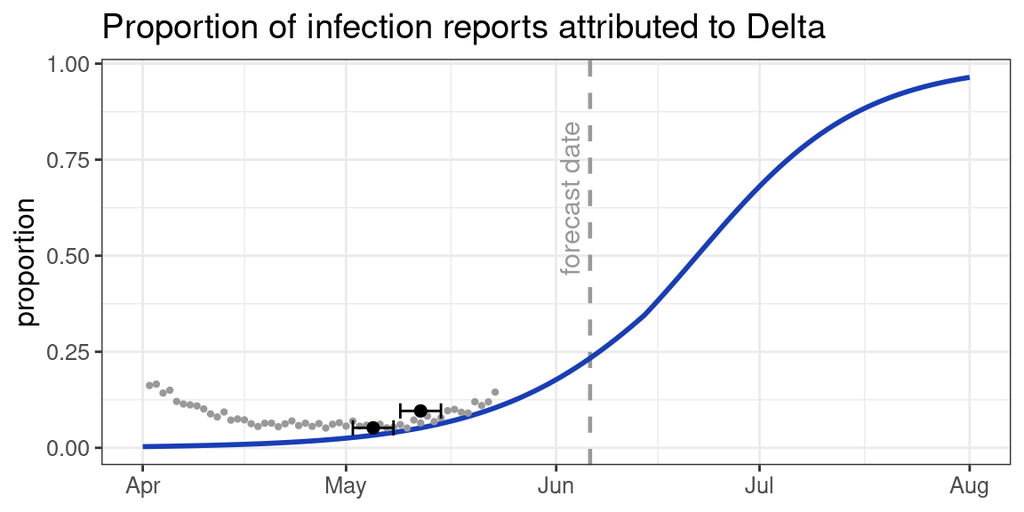

Related post: [Ontario COVID-19 forecasts, 16 May 2021](https://mac-theobio.github.io/forecasts/outputs/McMasterOntarioForecastsBlog2021-05-20)

[Back to the MacTheobio COVID Modelling Group page](https://mac-theobio.github.io/covid-19/)

[^1]: This report has been written independently of the Ontario Modelling Consensus Table, the Ontario Science Advisory Table, and the Health Coordination Table. The views expressed in this report are solely the authors’.